# Characterizing Trends in the Mean

Many factors can produce *nonstationarity* in annual maximum series (AMS) data, including changes in climate, land use/cover, and water management. This vignette demonstrates how to use the `ffaframework` to check for evidence of nonstationarity in the mean of a time series.

## List of Tests

**Mean Trend Tests**

| Function | Purpose |
| --- | --- |
| `eda_mk_test` | Tests for a monotonic trend (Mann-Kendall test). |
| `eda_bbmk_test` | Tests for a monotonic trend under serial correlation (BBMK test). |

**Stationarity Tests**

| Function | Purpose |
| --- | --- |
| `eda_spearman_test` | Tests for serial correlation (Spearman test). |
| `eda_kpss_test` | Tests for a stochastic trend (KPSS test). |
| `eda_pp_test` | Tests for a deterministic trend (Phillips-Perron test). |

**Variability Trend Tests**

| Function | Purpose |
| --- | --- |
| MW-MK Test | Tests for a trend in the variability (MWMK test) |
| `eda_white_test` | Tests for time-dependence in the variability (White test). |

**Trend Estimation (Mean & Variability)**

| Function | Purpose |
| --- | --- |
| `eda_sens_trend` | Estimates slope and intercept of a linear trend (Sen’s trend estimator). |
| `eda_runs_test` | Evaluates residuals’ structure under linear model assumptions (runs test). |

## Case Study

This vignette will explore data from the Bow River at Banff (05BB001) hydrological monitoring station. The remoteness of this station means that trends annual maxima are caused by changes in climate as opposed to changes in land use or cover. Data for this station is provided as `CAN-05BB001.csv` in the `ffaframework` package.

```r
library(ffaframework)

df <- data_local("CAN-05BB001.csv")
head(df)
```

```
#>   year max
#> 1 1909 314
#> 2 1910 230
#> 3 1911 264
#> 4 1912 174
#> 5 1913 232
#> 6 1914 214
```

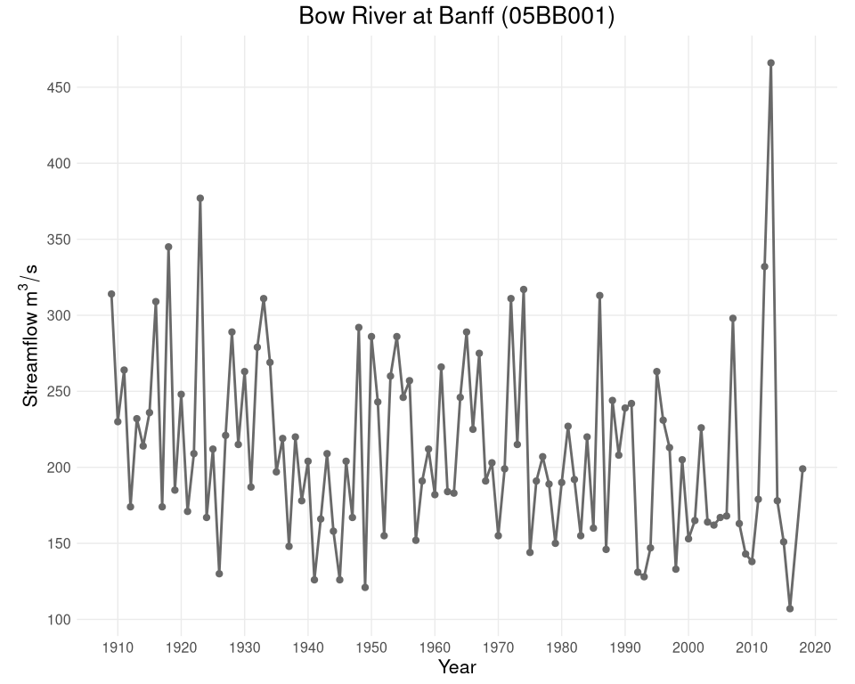

```r
plot_ams_data(df$max, df$year, title = "Bow River at Banff (05BB001)")
```

## Assessing Trends in the Mean

### Mann-Kendall Test

The Mann-Kendall test is a non-parametric test used to detect monotonic trends in a time series. Under the null hypothesis, there is no trend.

Pass a vector of annual maximum series (AMS) data to `eda_mk_test()` to perform the Mann-Kendall test.

```r
mk_test <- eda_mk_test(df$max)

print(mk_test$p_value)
```

```
#> [1] 0.006773098
```

**Conclusion**: At a p-value of $0.0067$, we *reject* the null hypothesis. There is statistical evidence of a trend in the mean.

### Spearman Test

The Spearman test is used to check for *serial correlation*, which can cause the Mann-Kendall test to identify a spurious trend. The smallest lag at which the serial correlation is not statistically significant is known as the “least lag”.

```r
spearman_test <- eda_spearman_test(df$max)

print(spearman_test$least_lag)
```

```
#> [1] 1
```

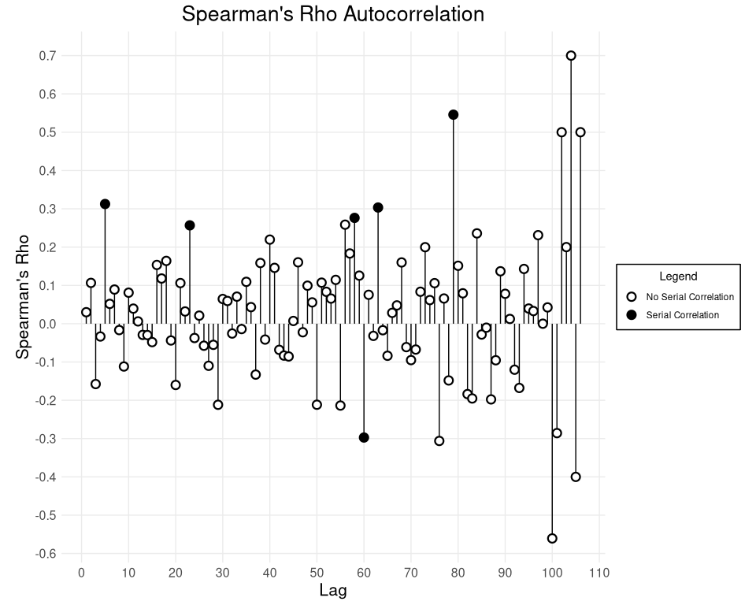

```r
plot_spearman_test(spearman_test)
```

**Conclusion**: A least lag of 1 provides no evidence of serial correlation.

### Further Tests

If the Spearman test identified serial correlation, we would use the BBMK test (with `eda_bbmk_test`) to check for a monotonic trend under serial correlation. The BBMK test uses a reshuffling procedure to remove serial correlation from the data.

The Phillips-Perron (`eda_pp_test`) and KPSS (`eda_kpss_test`) tests are used to check for a unit root (or *stochastic trend*) in the data. A unit root is an extreme type of serial correlation that creates unpredictable variation in the data. Since we did not find evidence of serial correlation in the Spearman test, it is not necessary to apply these tests. The Phillips-Perron and KPSS tests have opposite hypotheses: the Phillips-Perron assumes the presence of a unit root as the null hypothesis, while the KPSS test does not.

### Sen’s Trend Estimator

While the Mann-Kendall identified a significant monotonic trend, it did not estimate its slope or intercept. We can estimate the monotonic trend using Sen’s trend estimator, which uses a non-parametric approach that is robust to outliers.

`eda_sens_trend()` takes two arguments: the annual maximum series and the corresponding vector of years. Then, `plot_ams_data()` can be used to generate a plot of the results. It requires the AMS data and corresponding vector of years. It also takes an optional arguments `plot_mean` and `plot_variability` for plotting a trend in the mean and variability respectively.

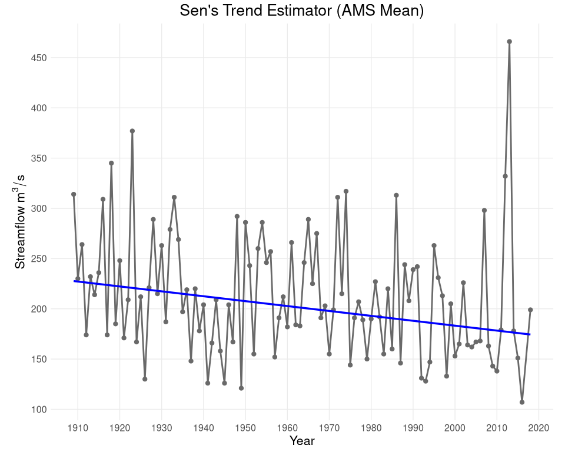

```r
plot_ams_data(
    df$max,
    df$year,
    plot_mean = "Trend",
    title = "Sen's Trend Estimator (AMS Mean)"
)
```

**Note**: The covariate is computed using the formula $(\text{years} - 1900) / 100$.

### Runs Test

The previous statistical tests have assumed the nonstationarity is linear. The runs test assess the feasibility of the linearity assumption by checking the residuals for randomness. Alternatively, `plot_ams_data()` can be used to run Sen’s trend estimator on the data and/or variability series and then plot the results. It takes the optional arguments `plot_mean` and `plot_variability` in addition to the `data` and `years`.

```r
sens_trend <- eda_sens_trend(df$max, df$year)

runs_test <- eda_runs_test(sens_trend$residuals, df$year)

print(runs_test$p_value)
```

```
#> [1] 0.4392721
```

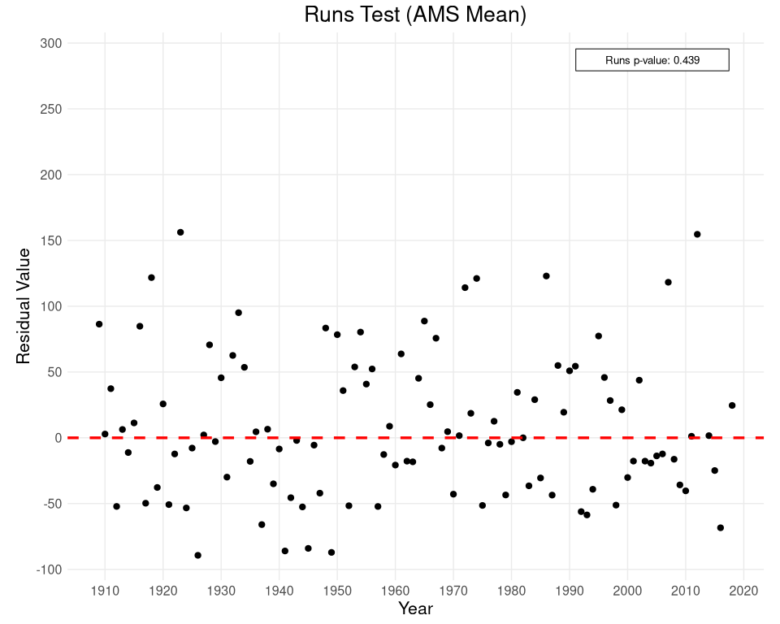

```r
plot_runs_test(runs_test, title = "Runs Test (AMS Mean)")
```

## Conclusion

The Mann-Kendall test identified *evidence of nonstationarity in the mean of the AMS*. The Spearman test *did not find evidence of serial correlation*, validating the results of the Mann-Kendall test. The runs test found that a *linear model is suitable for the nonstationarity*. Flood frequency analysis of this dataset requires a time-dependent probability model.

**Recommendation**: Use NS-FFA.